# Prediction Assignment on HAR Dataset

Dooratharsini Paskaran

11/17/2021

## Summary

Using devices such as Jawbone Up, Nike FuelBand, and Fitbit it is now possible to collect a large amount of data about personal activity relatively inexpensively. We use data from accelerometers on the belt, forearm, arm, and dumbell of 6 participants.  
The goal of this project is to predict the manner in which they did the exercise. We use the “classe” variable in the datasets. This report will describes how model build using cross validation and took the expected out of sample error. Finally predict 20 different test cases using the prediction model.

This document summarizes the write up for the Prediction Assignment on HAR data for the Coursera Practical Machine Learning course project.

## Load required packages

```r
knitr::opts_chunk$set(echo = TRUE, warning = FALSE, message = FALSE)
library(caret)
```

```r
library(ggplot2)
library(gbm)
```

## Download training and testing data

```r
setwd("C:/MyFolders/Coursera/Course8/ProjectHARDataset")

if (!file.exists("C:/MyFolders/Coursera/Course8/ProjectHARDataset/pml-training.csv")){
  fileurl <- "https://d396qusza40orc.cloudfront.net/predmachlearn/pml-training.csv"
   download.file(fileurl, "pml-training.csv", method = "curl")
}

if (!file.exists("C:/MyFolders/Coursera/Course8/ProjectHARDataset/pml-testing.csv")){
  fileurl <- "https://d396qusza40orc.cloudfront.net/predmachlearn/pml-testing.csv"
   download.file(fileurl, "pml-testing.csv", method = "curl")
}
```

## Load the training and testing data

```r
trainHARData <- read.csv("C:/MyFolders/Coursera/Course8/ProjectHARDataset/pml-training.csv", header = TRUE)
testHARData <- read.csv("C:/MyFolders/Coursera/Course8/ProjectHARDataset/pml-testing.csv", header = TRUE)
```

## Now split the training into to as actual testing and validation

Here, we split the training data into training and validation datasets.70% of training data to actually train our model and the remaining 30% to validate it.

```r
set.seed(1213)

inTrainHARData <- createDataPartition(y=trainHARData$classe, p=.7, list = FALSE)

training <- trainHARData[inTrainHARData,]
validation <- trainHARData[-inTrainHARData,]
```

## Removing zero covariates

Next, we prepare the data for modeling. There are a number of variables that have zero variance or high missing values. To avoid using these variables in algorithms which gives meaningless predictions. Therefore, we remove zero covariates and almost all are missing variables for meaningful modeling.

```r
nzv <- nearZeroVar(training)
training <- training[,-nzv]
validation <- validation[,-nzv]
dim(training)
```

```
## [1] 13737   104
```

```r
dim(validation)
```

```
## [1] 5885  104
```

## Removing NA columns

```r
allNA <- sapply(training,function(x) mean(is.na(x))) > 0.95
training <- training[,allNA==FALSE]
validation <- validation[,allNA==FALSE]
training <- training[,-(1:5)]
validation <- validation[,-(1:5)]
dim(training)
```

```
## [1] 13737    54
```

```r
dim(validation)
```

```
## [1] 5885   54
```

Now we have clean data for building models.  
We will build two models:  
1. Random forest  
2. Generalized boosted model  
We train these in the training data of the actual training dataset and then test them in the validation set of the actual training dataset.

## Build Random Forest Model

```r
set.seed(1213)
modFitRF <- train(classe ~., data=training, method="rf",
                  trControl = trainControl(method="cv",number=3,verboseIter=FALSE))

modFitRF$finalModel
```

```
##
## Call:
##  randomForest(x = x, y = y, mtry = min(param$mtry, ncol(x)))
##                Type of random forest: classification
##                      Number of trees: 500
## No. of variables tried at each split: 27
##
##         OOB estimate of  error rate: 0.25%
## Confusion matrix:
##      A    B    C    D    E  class.error
## A 3904    1    0    0    1 0.0005120328
## B    7 2646    4    1    0 0.0045146727
## C    0    8 2388    0    0 0.0033388982
## D    0    0    7 2244    1 0.0035523979
## E    0    0    0    5 2520 0.0019801980
```

## Build Generalised Boosted Model

```r
set.seed(1213)
modFitGBM <- train(classe ~. , data = training, method = "gbm", verbose=FALSE ,
                   trControl = trainControl(method="repeatedcv",number = 5,repeats = 1))
print(modFitGBM)
```

```
## Stochastic Gradient Boosting
##
## 13737 samples
##    53 predictor
##     5 classes: 'A', 'B', 'C', 'D', 'E'
##
## No pre-processing
## Resampling: Cross-Validated (5 fold, repeated 1 times)
## Summary of sample sizes: 10988, 10990, 10990, 10990, 10990
## Resampling results across tuning parameters:
##
##   interaction.depth  n.trees  Accuracy   Kappa
##   1                   50      0.7613745  0.6972808
##   1                  100      0.8309668  0.7859848
##   1                  150      0.8712965  0.8370705
##   2                   50      0.8813416  0.8497502
##   2                  100      0.9373226  0.9206901
##   2                  150      0.9625103  0.9525710
##   3                   50      0.9298247  0.9111757
##   3                  100      0.9713913  0.9638046
##   3                  150      0.9863872  0.9827797
##
## Tuning parameter 'shrinkage' was held constant at a value of 0.1
##
## Tuning parameter 'n.minobsinnode' was held constant at a value of 10
## Accuracy was used to select the optimal model using the largest value.
## The final values used for the model were n.trees = 150, interaction.depth =
##  3, shrinkage = 0.1 and n.minobsinnode = 10.
```

## Validating the models

Models built, here we check the performance of these two models in the validation dataset. We predict the values in the validation set, and then comparing the predictions with the actual values.

```r
predictionValidationModRF <- predict(modFitRF, validation)
confusionMatrixRF <- confusionMatrix(predictionValidationModRF, as.factor(validation$classe))
print(confusionMatrixRF)
```

```
## Confusion Matrix and Statistics
##
##           Reference
## Prediction    A    B    C    D    E
##          A 1674    2    0    0    0
##          B    0 1134    3    0    0
##          C    0    3 1023    5    0
##          D    0    0    0  959    5
##          E    0    0    0    0 1077
##
## Overall Statistics
##
##                Accuracy : 0.9969
##                  95% CI : (0.9952, 0.9982)
##     No Information Rate : 0.2845
##     P-Value [Acc > NIR] : < 2.2e-16
##
##                   Kappa : 0.9961
##
##  Mcnemar's Test P-Value : NA
##
## Statistics by Class:
##
##                      Class: A Class: B Class: C Class: D Class: E
## Sensitivity            1.0000   0.9956   0.9971   0.9948   0.9954
## Specificity            0.9995   0.9994   0.9984   0.9990   1.0000
## Pos Pred Value         0.9988   0.9974   0.9922   0.9948   1.0000
## Neg Pred Value         1.0000   0.9989   0.9994   0.9990   0.9990
## Prevalence             0.2845   0.1935   0.1743   0.1638   0.1839
## Detection Rate         0.2845   0.1927   0.1738   0.1630   0.1830
## Detection Prevalence   0.2848   0.1932   0.1752   0.1638   0.1830
## Balanced Accuracy      0.9998   0.9975   0.9977   0.9969   0.9977
```

```r
predictionValidationModGBM <- predict(modFitGBM, validation)
confusionMatrixGBM <- confusionMatrix(predictionValidationModGBM, as.factor(validation$classe))
print(confusionMatrixGBM)
```

```
## Confusion Matrix and Statistics
##
##           Reference
## Prediction    A    B    C    D    E
##          A 1668   12    0    0    0
##          B    4 1114    8    3    6
##          C    0   13 1016   17    2
##          D    2    0    1  943    9
##          E    0    0    1    1 1065
##
## Overall Statistics
##
##                Accuracy : 0.9866
##                  95% CI : (0.9833, 0.9894)
##     No Information Rate : 0.2845
##     P-Value [Acc > NIR] : < 2.2e-16
##
##                   Kappa : 0.983
##
##  Mcnemar's Test P-Value : NA
##
## Statistics by Class:
##
##                      Class: A Class: B Class: C Class: D Class: E
## Sensitivity            0.9964   0.9781   0.9903   0.9782   0.9843
## Specificity            0.9972   0.9956   0.9934   0.9976   0.9996
## Pos Pred Value         0.9929   0.9815   0.9695   0.9874   0.9981
## Neg Pred Value         0.9986   0.9947   0.9979   0.9957   0.9965
## Prevalence             0.2845   0.1935   0.1743   0.1638   0.1839
## Detection Rate         0.2834   0.1893   0.1726   0.1602   0.1810
## Detection Prevalence   0.2855   0.1929   0.1781   0.1623   0.1813
## Balanced Accuracy      0.9968   0.9868   0.9918   0.9879   0.9919
```

## Plots

We investigate the generalized boosted model a bit further to see which variables have the highest relative importance.

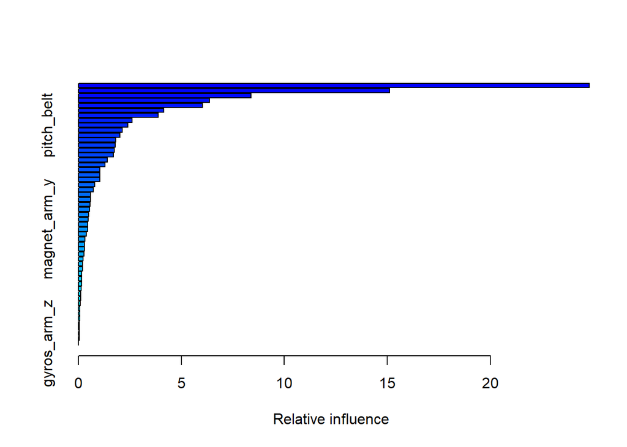

```
##                                       var      rel.inf
## num_window                     num_window 24.803659734
## roll_belt                       roll_belt 15.111719669
## pitch_forearm               pitch_forearm  8.374741277
## yaw_belt                         yaw_belt  6.378813743
## magnet_dumbbell_z       magnet_dumbbell_z  6.030848148
## magnet_dumbbell_y       magnet_dumbbell_y  4.156587732
## roll_forearm                 roll_forearm  3.867848683
## magnet_belt_z               magnet_belt_z  2.597953155
## pitch_belt                     pitch_belt  2.401949791
## roll_dumbbell               roll_dumbbell  2.127833410
## accel_dumbbell_z         accel_dumbbell_z  2.026138565
## accel_dumbbell_y         accel_dumbbell_y  1.805447799
## accel_forearm_x           accel_forearm_x  1.783572067
## gyros_dumbbell_y         gyros_dumbbell_y  1.745846821
## gyros_belt_z                 gyros_belt_z  1.702914080
## magnet_forearm_z         magnet_forearm_z  1.414063192
## accel_dumbbell_x         accel_dumbbell_x  1.302071148
## accel_forearm_z           accel_forearm_z  1.054492444
## yaw_arm                           yaw_arm  1.050099974
## magnet_belt_x               magnet_belt_x  1.040331823
## roll_arm                         roll_arm  0.791645253
## magnet_arm_x                 magnet_arm_x  0.730769194
## magnet_arm_z                 magnet_arm_z  0.594017874
## accel_belt_z                 accel_belt_z  0.587075461
## magnet_belt_y               magnet_belt_y  0.558984447
## gyros_arm_y                   gyros_arm_y  0.544439751
## gyros_belt_y                 gyros_belt_y  0.500497135
## magnet_forearm_x         magnet_forearm_x  0.488395625
## magnet_dumbbell_x       magnet_dumbbell_x  0.461737288
## magnet_arm_y                 magnet_arm_y  0.450679994
## total_accel_dumbbell total_accel_dumbbell  0.384636394
## pitch_dumbbell             pitch_dumbbell  0.329152396
## gyros_dumbbell_x         gyros_dumbbell_x  0.292503980
## gyros_arm_x                   gyros_arm_x  0.288885506
## accel_arm_x                   accel_arm_x  0.266653289
## gyros_dumbbell_z         gyros_dumbbell_z  0.222267901
## accel_forearm_y           accel_forearm_y  0.204746655
## accel_arm_y                   accel_arm_y  0.199260788
## gyros_forearm_z           gyros_forearm_z  0.165835878
## accel_arm_z                   accel_arm_z  0.163125064
## total_accel_forearm   total_accel_forearm  0.151462750
## magnet_forearm_y         magnet_forearm_y  0.147756491
## gyros_forearm_y           gyros_forearm_y  0.110179829
## pitch_arm                       pitch_arm  0.108970299
## yaw_forearm                   yaw_forearm  0.094796344
## total_accel_belt         total_accel_belt  0.077619212
## gyros_forearm_x           gyros_forearm_x  0.072283888
## gyros_belt_x                 gyros_belt_x  0.069908761
## accel_belt_y                 accel_belt_y  0.045136109
## yaw_dumbbell                 yaw_dumbbell  0.039731402
## accel_belt_x                 accel_belt_x  0.039643820
## total_accel_arm           total_accel_arm  0.038658420
## gyros_arm_z                   gyros_arm_z  0.001609548
```

```r
print(summary(modFitGBM))
```

The above list shows the importance of variables in GB Model. We see that num_window, roll_belt, and pitch_forearm are most important. We can checkout the feature plot below.

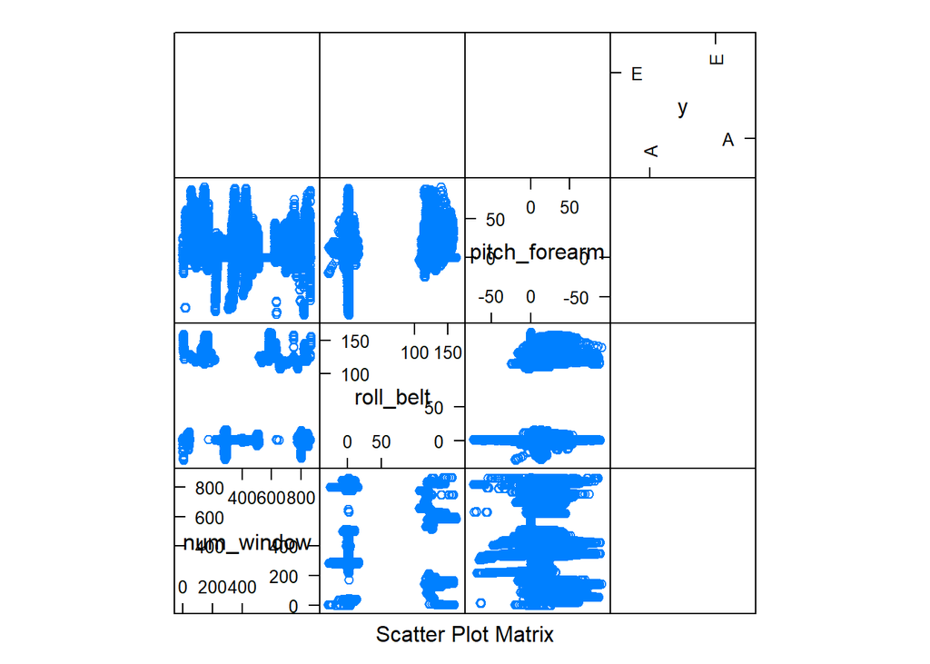

```r
featurePlot(x=training[, c("num_window","roll_belt","pitch_forearm")], y=training$classe, plot="pairs")
```

## Predict on the actual test data

We see the random forest performs (Accuracy : 0.9969) better than the generalized boosted model (Accuracy : 0.9866). Let’s test our model in the actual testing dataset.

```r
predictTestWithModRF <- predict(modFitRF, newdata = testHARData)
print(predictTestWithModRF)
```

```
##  [1] B A B A A E D B A A B C B A E E A B B B
## Levels: A B C D E
```